# Children at Risk: Sanitation, Poverty & Child Mortality

A UNICEF Data Analysis Report

Author

Madhuri

Published

April 14, 2026

```python
!pip install polars plotnine geopandas pyogrio pyarrow geodatasets --quiet
```

## Introduction

This is the story this report tells.

> *Behind every data point is a life, and behind every trend line, a generation of children who deserved better.*

### The Data

- **unicef_indicator_1.csv** — Proportion of schools with limited sanitation, by country and year
- **unicef_indicator_2.csv** — Deaths of children aged 5–9, by country and year
- **unicef_metadata.csv** — GDP per capita, life expectancy and population by country

```python
import polars as pl
import pandas as pd
import geopandas as gpd
import matplotlib
matplotlib.use('Agg')
from plotnine import *
import warnings
warnings.filterwarnings('ignore')

unicef_indicator_1 = pl.read_csv("unicef_indicator_1.csv")
unicef_indicator_2 = pl.read_csv("unicef_indicator_2.csv")
unicef_metadata    = pl.read_csv("unicef_metadata.csv")

san = (
    unicef_indicator_1
    .filter(pl.col("sex") == "Total")
    .rename({
        "time_period":  "year",
        "obs_value":    "pct_limited_sanitation",
        "alpha_3_code": "iso3"
    })
    .select(["country", "iso3", "year", "pct_limited_sanitation"])
    .drop_nulls()
)

deaths = (
    unicef_indicator_2
    .filter(pl.col("sex") == "Total")
    .rename({
        "time_period":  "year",
        "obs_value":    "deaths_5_9",
        "alpha_3_code": "iso3"
    })
    .select(["country", "iso3", "year", "deaths_5_9"])
    .drop_nulls()
)

meta = (
    unicef_metadata
    .rename({
        "alpha_3_code":                            "iso3",
        "GDP per capita (constant 2015 US$)":      "gdp_per_capita",
        "Life expectancy at birth, total (years)": "life_expectancy",
        "Population, total":                       "population",
        "Birth rate, crude (per 1,000 people)":    "birth_rate"
    })
    .select(["country", "iso3", "year", "gdp_per_capita",
             "life_expectancy", "population", "birth_rate"])
    .drop_nulls(subset=["iso3"])
)

combined = (
    deaths
    .join(meta, on=["iso3", "year"], how="inner")
    .drop_nulls(subset=["gdp_per_capita", "life_expectancy", "population"])
)

avg_deaths = (
    combined
    .group_by(["country", "iso3"])
    .agg(pl.col("deaths_5_9").mean().alias("avg_deaths"))
    .sort("avg_deaths", descending=True)
)

print(f"Combined dataset : {combined.shape[0]:,} rows")
print(f"Unique countries : {combined['iso3'].n_unique()}")
print(f"Year range       : {combined['year'].min()} to {combined['year'].max()}")
```

```
Combined dataset : 6,409 rows
Unique countries : 192
Year range       : 1990 to 2023
```

## Where Children Die: A World Divided by Wealth

The first question is: **which parts of the world carry the greatest burden of child mortality?**

We map average annual child deaths (ages 5–9) per country across all available years. Countries in **grey** have no data.

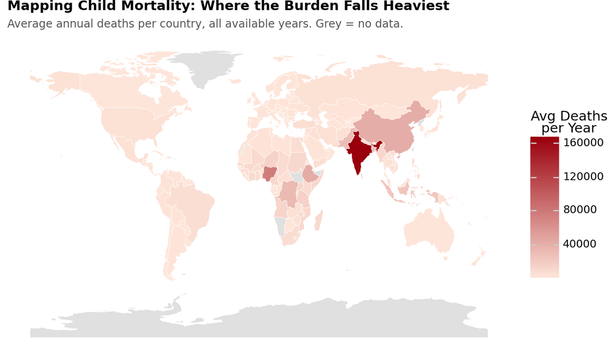

```python
world_geo = gpd.read_file(
    "https://raw.githubusercontent.com/nvkelso/natural-earth-vector/master/geojson/ne_110m_admin_0_countries.geojson"
)
world_geo = world_geo[["ADM0_A3", "geometry"]].rename(columns={"ADM0_A3": "iso3"})

avg_pd  = avg_deaths.to_pandas()
map_gdf = world_geo.merge(avg_pd, on="iso3", how="left")

(
    ggplot(map_gdf)
    + geom_map(aes(fill="avg_deaths"), color="white", size=0.15)
    + scale_fill_gradient(
        low="#fee5d9", high="#99000d",
        na_value="#e0e0e0",
        name="Avg Deaths\nper Year"
    )
    + coord_fixed(ratio=1.3)
    + labs(
        title="Mapping Child Mortality: Where the Burden Falls Heaviest",
        subtitle="Average annual deaths per country, all available years. Grey = no data.",
        x="", y=""
    )
    + theme_void()
    + theme(
        figure_size=(7, 4),
        plot_title=element_text(size=11, face="bold"),
        plot_subtitle=element_text(size=9, color="#555555"),
        legend_position="right"
    )
)
```

> **Key insight:** Child deaths are heavily concentrated in **Sub-Saharan Africa** and parts of **South Asia**. These are not random patterns — they reflect decades of poverty, limited healthcare, and inadequate infrastructure. High-income regions like North America and Western Europe are nearly invisible on this scale.

*Top 10 countries by average annual child deaths (ages 5–9)*

```python
from IPython.display import display, HTML

top10_table = (
    avg_deaths.head(10)
    .to_pandas()
    .reset_index(drop=True)
)
top10_table.index = top10_table.index + 1
top10_table = top10_table[["country", "avg_deaths"]].rename(
    columns={"country": "Country", "avg_deaths": "Avg Deaths / Year"}
)
top10_table["Avg Deaths / Year"] = top10_table["Avg Deaths / Year"].round(0).astype(int)
display(HTML(top10_table.to_html(classes="table table-striped table-sm", border=0)))
```

|  | Country | Avg Deaths / Year |
| --- | --- | --- |
| 1 | India | 167712 |
| 2 | Nigeria | 76721 |
| 3 | Ethiopia | 42079 |
| 4 | China | 40475 |
| 5 | Congo, the Democratic Republic of the | 30805 |
| 6 | Pakistan | 28175 |
| 7 | Bangladesh | 24666 |
| 8 | Indonesia | 22585 |
| 9 | Tanzania, United Republic of | 14331 |
| 10 | Niger | 12872 |

## The Heaviest Burden: Ten Countries Facing a Child Mortality Crisis

Which countries face the most severe child mortality challenge? This bar chart ranks the **top 10 countries** by average annual deaths in the 5–9 age group, coloured by severity.

> **Note:** Absolute numbers partly reflect **large population sizes**. Nigeria and India rank high partly because they are among the world’s most populous nations — not only because of poor health outcomes.

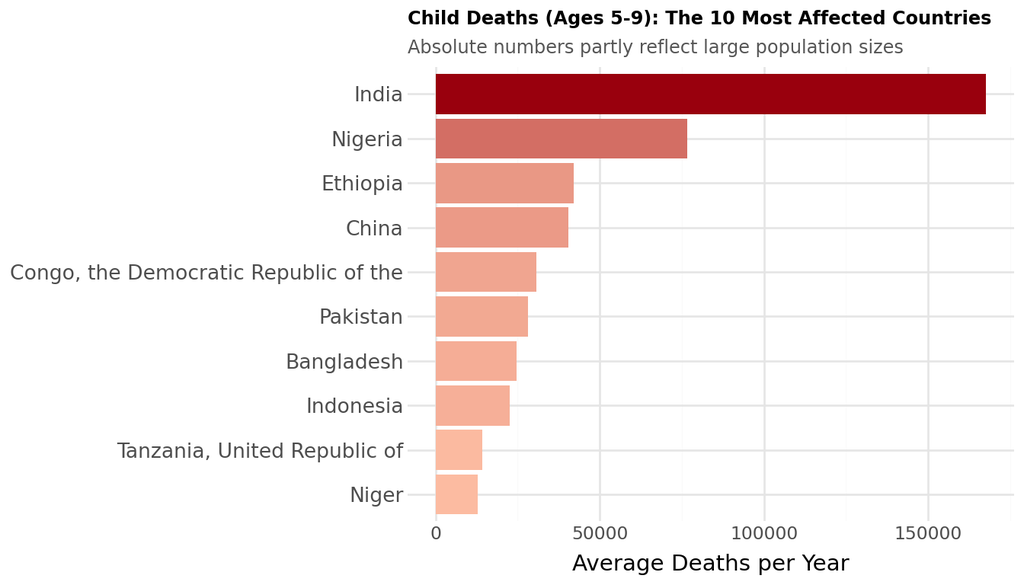

```python
top10 = avg_deaths.head(10).to_pandas()

top10["country"] = pd.Categorical(
    top10["country"],
    categories=top10.sort_values("avg_deaths")["country"],
    ordered=True
)

(
    ggplot(top10, aes(x="country", y="avg_deaths", fill="avg_deaths"))
    + geom_col()
    + coord_flip()
    + scale_fill_gradient(low="#fcbba1", high="#99000d")
    + labs(
        title="Child Deaths (Ages 5-9): The 10 Most Affected Countries",
        subtitle="Absolute numbers partly reflect large population sizes",
        x="", y="Average Deaths per Year"
    )
    + theme_minimal()
    + theme(
        figure_size=(7, 4),
        plot_title=element_text(size=9, face="bold"),
        plot_subtitle=element_text(size=9, color="#555555"),
        axis_text_y=element_text(size=10),
        legend_position="none"
    )
)
```

> **Important context:** Nigeria and India dominate this chart partly because they are among the world’s **most populous nations**. The number of deaths reflects both the mortality *rate* and the *size* of the child population.

*Ranked list of the 10 most affected countries by average annual deaths*

```python
bar_table = (
    avg_deaths.head(10)
    .to_pandas()
    .sort_values("avg_deaths", ascending=False)
    .reset_index(drop=True)
)
bar_table.index = bar_table.index + 1
bar_table = bar_table[["country", "avg_deaths"]].rename(
    columns={"country": "Country", "avg_deaths": "Avg Deaths / Year"}
)
bar_table["Avg Deaths / Year"] = bar_table["Avg Deaths / Year"].round(0).astype(int)
display(HTML(bar_table.to_html(classes="table table-striped table-sm", border=0)))
```

|  | Country | Avg Deaths / Year |
| --- | --- | --- |
| 1 | India | 167712 |
| 2 | Nigeria | 76721 |
| 3 | Ethiopia | 42079 |
| 4 | China | 40475 |
| 5 | Congo, the Democratic Republic of the | 30805 |
| 6 | Pakistan | 28175 |
| 7 | Bangladesh | 24666 |
| 8 | Indonesia | 22585 |
| 9 | Tanzania, United Republic of | 14331 |
| 10 | Niger | 12872 |

## Economic Development & Child Survival: Examining the Evidence

This scatterplot forms the analytical core of the report. Each point represents a country, plotted against four dimensions simultaneously:

- **X-axis:** GDP per capita (constant 2015 US$) — a proxy for national economic development, displayed on a logarithmic scale
- **Y-axis:** Child mortality rate per 100,000 population (ages 5–9)
- **Colour:** Life expectancy at birth — green indicates higher longevity, red indicates lower
- **Regression line:** Ordinary Least Squares (OLS) trend across all countries

The hypothesis: **nations with higher per capita income exhibit significantly lower rates of child mortality.**

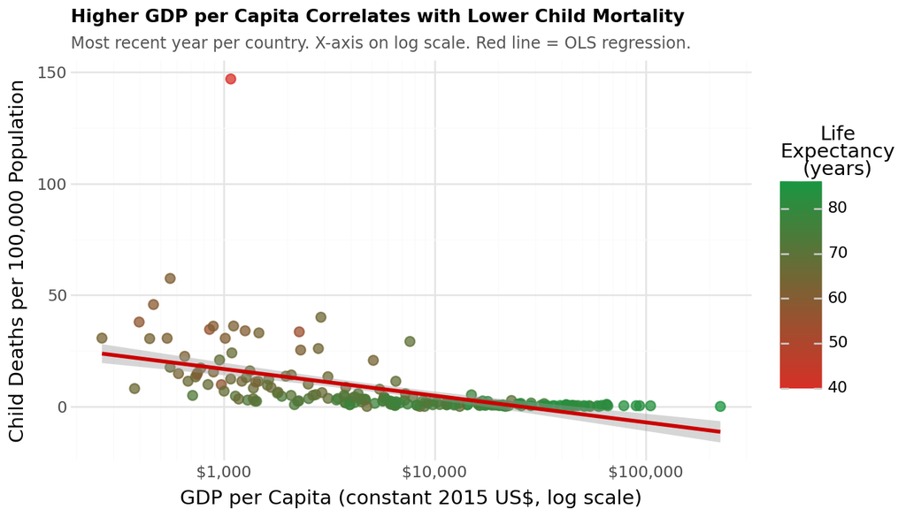

```python
scatter_d = (
    combined
    .sort("year", descending=True)
    .group_by("iso3")
    .first()
    .with_columns(
        (pl.col("deaths_5_9") / pl.col("population") * 100_000)
        .alias("deaths_per_100k")
    )
    .drop_nulls(subset=["deaths_per_100k", "gdp_per_capita"])
    .to_pandas()
)

(
    ggplot(scatter_d, aes(x="gdp_per_capita", y="deaths_per_100k"))
    + geom_point(aes(color="life_expectancy"), alpha=0.75, size=2.5)
    + geom_smooth(method="lm", color="#cc0000", se=True, size=1.2)
    + scale_x_log10(labels=lambda l: [f"${x:,.0f}" for x in l])
    + scale_color_gradient(
        low="#d73027", high="#1a9641",
        name="Life\nExpectancy\n(years)"
    )
    + labs(
        title="Higher GDP per Capita Correlates with Lower Child Mortality",
        subtitle="Most recent year per country. X-axis on log scale. Red line = OLS regression.",
        x="GDP per Capita (constant 2015 US$, log scale)",
        y="Child Deaths per 100,000 Population"
    )
    + theme_minimal()
    + theme(
        figure_size=(7, 4),
        plot_title=element_text(size=10, face="bold"),
        plot_subtitle=element_text(size=9, color="#555555")
    )
)
```

> **Key finding:** There is a **strong negative relationship** — as GDP per capita rises, child mortality falls sharply. Countries in the **top-left** (low GDP, high mortality) are overwhelmingly in Sub-Saharan Africa, confirming that poverty damages child health across *multiple dimensions* simultaneously.

*Average child mortality rate and life expectancy by GDP income group*

```python
scatter_d["GDP Group"] = pd.cut(
    scatter_d["gdp_per_capita"],
    bins=[0, 1000, 5000, 20000, float("inf")],
    labels=["Low (<$1,000)", "Lower-Middle ($1,000-$5,000)",
            "Upper-Middle ($5,000-$20,000)", "High (>$20,000)"]
)

gdp_summary = (
    scatter_d.groupby("GDP Group", observed=True)
    .agg(
        Countries=("iso3", "count"),
        Avg_Deaths_per_100k=("deaths_per_100k", "mean"),
        Avg_Life_Expectancy=("life_expectancy", "mean")
    )
    .round(1)
    .reset_index()
    .rename(columns={
        "Avg_Deaths_per_100k": "Avg Deaths per 100k",
        "Avg_Life_Expectancy": "Avg Life Expectancy (yrs)"
    })
)
display(HTML(gdp_summary.to_html(classes="table table-striped table-sm", border=0, index=False)))
```

| GDP Group | Countries | Avg Deaths per 100k | Avg Life Expectancy (yrs) |
| --- | --- | --- | --- |
| Low (<$1,000) | 22 | 22.6 | 63.2 |
| Lower-Middle ($1,000-$5,000) | 64 | 11.5 | 68.7 |
| Upper-Middle ($5,000-$20,000) | 61 | 2.6 | 74.8 |
| High (>$20,000) | 45 | 0.5 | 81.4 |

## Three Decades of Change: Progress, But Not for All

- **Nigeria** — highest burden in Sub-Saharan Africa
- **India** — largest population in South Asia
- **Brazil** — middle income, Latin America
- **China** — rapid economic development success story
- **United States** — high income benchmark
- **Ethiopia** — low income, Sub-Saharan Africa

The trajectories tell a story of **hope and persistent inequality** side by side.

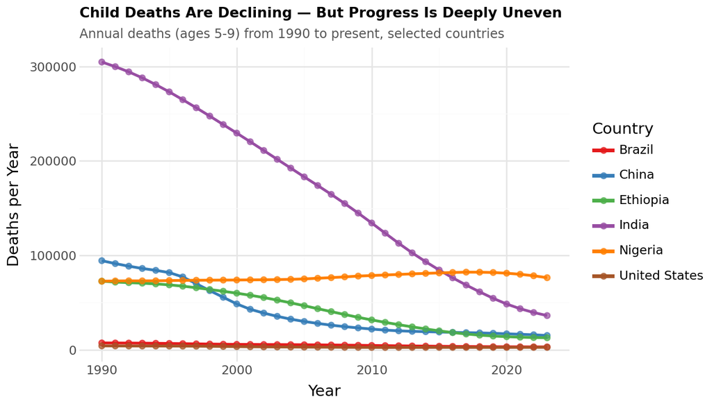

```python
selected_countries = ["Nigeria", "India", "Brazil", "China", "United States", "Ethiopia"]

line_d = (
    combined
    .filter(pl.col("country").is_in(selected_countries))
    .sort("year")
    .to_pandas()
)

(
    ggplot(line_d, aes(x="year", y="deaths_5_9", color="country", group="country"))
    + geom_line(size=1.1)
    + geom_point(size=1.8, alpha=0.7)
    + scale_color_manual(
        values=["#e41a1c", "#377eb8", "#4daf4a", "#984ea3", "#ff7f00", "#a65628"],
        name="Country"
    )
    + labs(
        title="Child Deaths Are Declining — But Progress Is Deeply Uneven",
        subtitle="Annual deaths (ages 5-9) from 1990 to present, selected countries",
        x="Year",
        y="Deaths per Year"
    )
    + theme_minimal()
    + theme(
        figure_size=(7, 4),
        plot_title=element_text(size=10, face="bold"),
        plot_subtitle=element_text(size=9, color="#555555"),
        legend_position="right"
    )
)
```

*Change in child deaths from earliest to latest available year, selected countries*

```python
ts_table = (
    line_d.groupby("country")
    .agg(
        From=("year", "min"),
        Deaths_Earliest=("deaths_5_9", "first"),
        To=("year", "max"),
        Deaths_Latest=("deaths_5_9", "last"),
    )
    .reset_index()
)

ts_table["Change (%)"] = (
    (ts_table["Deaths_Latest"] - ts_table["Deaths_Earliest"])
    / ts_table["Deaths_Earliest"] * 100
).round(1).astype(str) + "%"

ts_table[["Deaths_Earliest", "Deaths_Latest"]] = ts_table[
    ["Deaths_Earliest", "Deaths_Latest"]
].round(0).astype(int)

ts_table = ts_table.rename(columns={
    "country": "Country",
    "Deaths_Earliest": "Deaths (Earliest Year)",
    "Deaths_Latest": "Deaths (Latest Year)"
})

display(HTML(
    ts_table[["Country", "From", "Deaths (Earliest Year)", "To", "Deaths (Latest Year)", "Change (%)"]
    ].sort_values("Deaths (Latest Year)", ascending=False)
    .reset_index(drop=True)
    .to_html(classes="table table-striped table-sm", border=0, index=False)
))
```

| Country | From | Deaths (Earliest Year) | To | Deaths (Latest Year) | Change (%) |
| --- | --- | --- | --- | --- | --- |
| Nigeria | 1990 | 72584 | 2023 | 76308 | 5.1% |
| India | 1990 | 304742 | 2023 | 36162 | -88.1% |
| China | 1990 | 94312 | 2023 | 15075 | -84.0% |
| Ethiopia | 1990 | 72603 | 2023 | 12661 | -82.6% |
| Brazil | 1990 | 7206 | 2023 | 2983 | -58.6% |
| United States | 1990 | 4076 | 2023 | 2509 | -38.4% |

## What the Data Tells Us — and What Must Change

Four visualisations. Three decades of data. One hundred and fifty countries. The story they tell is uncomfortable but unmistakable.

### The Path Forward

> *Data does not lie, but it does demand a response. Every number in this report represents a child’s life.*

The evidence calls for **sustained, targeted investment** — in clean water, school sanitation, primary healthcare, and poverty reduction at scale. These are not abstract development goals. They are the specific conditions that keep children alive.

*Report created for BAA1030 – Data Analytics & Story Telling. Data source: UNICEF. All analysis conducted in Python using Polars and Plotnine.*